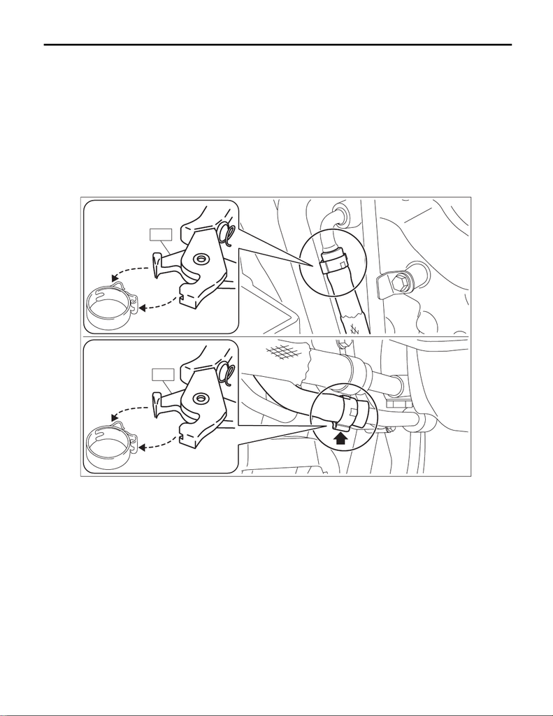

EC(w/o STI)-78

PCV Hose Assembly

EMISSION CONTROL (AUX. EMISSION CONTROL DEVICES)

16.PCV Hose Assembly

A: REMOVAL

CAUTION:

Do not remove except when the PCV hose assembly is broken.

1) Remove the air intake duct. <Ref. to IN(w/o STI)-22, REMOVAL, Air Intake Duct.>

2) Disconnect the PCV hose assembly from the chain cover, and remove the PCV hose assembly from the

oil catch tank.

NOTE:

To disconnect the PCV hose assembly, fit the cut outs of the ST with the protrusions on the clamp as shown

in the figure, squeeze the ST's handles together and unlock the clamp.

ST 18353AA000 CLAMP PLIERS

EC-03458

ST

ST

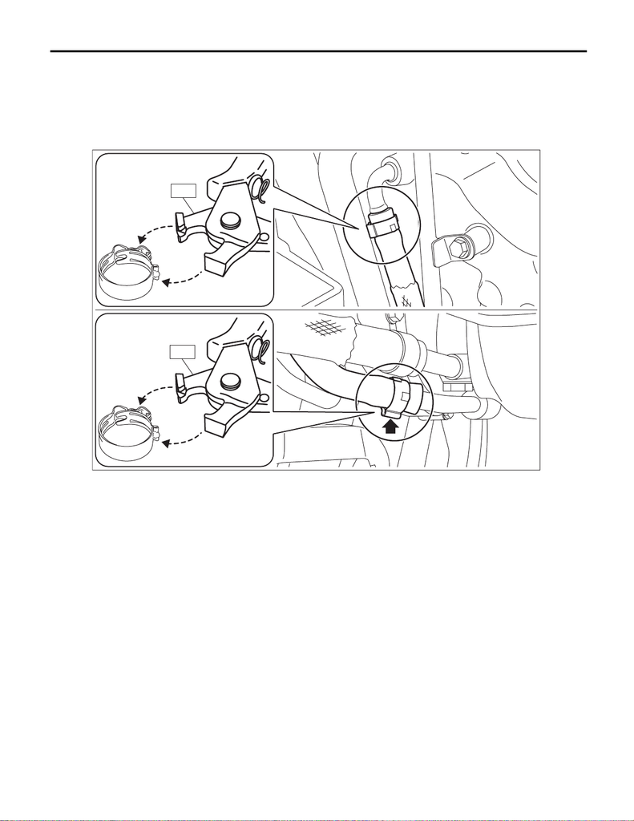

EC(w/o STI)-79

PCV Hose Assembly

EMISSION CONTROL (AUX. EMISSION CONTROL DEVICES)

B: INSTALLATION

Install in the reverse order of removal.

NOTE:

Use a new clamp. To connect the PCV hose assembly, fit the cut outs of the ST with the protrusions on the

clamp as shown in the figure, squeeze the ST's handles together and lock the clamp.

ST 18353AA000 CLAMP PLIERS

C: INSPECTION

Check the PCV hose assembly for cracks, damage or looseness.

EC-03457

ST

ST